# Dependent Means and Medians

## Introduction

- In the last module, we reviewed statistical inference for one sample.
- In this module, we will focus on tests for two samples.
  - Two-sample independent means ($\mu_1-\mu_2$)
  - Two-sample dependent means ($\mu_d$)
  - Two-sample proportions ($\pi_1-\pi_2$)
  - Two-sample variances ($\sigma^2_1/\sigma^2_2$)
- In this lecture: two-sample dependent means ($\mu_d$)

## Introduction

- So far in this module, we have focused on independent samples.
  - Two-sample means, independent data ($\mu_1-\mu_2$).
  - Two-sample medians, independent data ($M_1-M_2$).
- In this lecture, we shift to dependent (paired) samples.
  - Two-sample means, dependent data ($\mu_d$)
  - Two-sample medians, dependent data ($M_d$)
- The data is *paired* because we can link the observations.
  - The two measurements come from the *same* subject.

## New Dataset!

- You’re still the ZPD’s data analyst, but Deputy Chief Okonkwo has a different kind of question for you this time.
  - Before now, every question asked involved comparing different groups of recruits
  - Now, the questions are about the same recruits, measured twice.
- Okonkwo wants to know whether things are *changing*:
  - Did coaching help?
  - Is fitness improving?
  - Did new software actually speed things up?

## `R` Setup

```r
library(tidyverse)
library(ssstats)
```

- Our new Zootopia data,

```r
zootopia_paired <- read_csv("https://raw.githubusercontent.com/samanthaseals/SDSI/refs/heads/main/files/data/lectures/2-zootopia-paired.csv")
```

| resident_name | exam_score_pre | exam_score_post | fitness_score_intake | fitness_score_6mo | response_time_before | response_time_after |
| --- | --- | --- | --- | --- | --- | --- |
| Piper Ravensmoor | 73 | 80 | 54 | 51 | 9.2 | 8.0 |
| Rufus Copperfield | 61 | 70 | 85 | 87 | 12.1 | 11.7 |
| Willa Grimsby | 72 | 74 | 67 | 70 | 6.0 | 5.3 |

## Why Not Independent?

- If we run `independent_means()` on either the “before” column or the “after” column, we are ignoring the pairing.
- Because the same recruit is measured twice, their two scores are correlated.
  - A recruit who scored high the first time will likely also score high the second time.
- Pairing lets us focus on *within-subject change*.

## Dependent Data

- For each subject $i$, we calculate one difference score:

$$d_i = y_{i1} - y_{i2}$$

- All of our inference is now built on this *single column of differences*, not the original columns.
  - i.e., This means dependent-samples inference is really just one-sample inference (mean or median), applied to $d$.

## Confidence Interval for $\mu_d$

- $(1-\alpha)100\%$ CI for a population mean difference, $\mu_d$

$$\bar{d} \pm t_{\alpha/2, n-1} \frac{s_d}{\sqrt{n}}$$

- $\bar{d}$ is the mean of the differences, $s_d$ is the standard deviation of the differences, and $n$ is the number of **pairs** (not the number of raw observations).
- $t$ has $n-1$ degrees of freedom (df).

## Hypothesis Test for $\mu_d$

**Hypotheses**

**Two-Tailed**

$H_0: \mu_d = \mu_0$

$H_1: \mu_d \ne \mu_0$

**Left-Tailed**

$H_0: \mu_d \ge \mu_0$

$H_1: \mu_d < \mu_0$

**Right-Tailed**

$H_0: \mu_d \le \mu_0$

$H_1: \mu_d > \mu_0$

- $\mu_d$ is the population mean of the differences,
  - Note that you must specify what $\mu_d$ is. e.g., $\mu_1-\mu_2$
- $\mu_0$ is the hypothesized value of that mean difference (often 0, for “no change”).

## Hypothesis Test for $\mu_d$

**Test Statistic:**

$$t_0 = \frac{\bar{d}-\mu_0}{{\dfrac{s_d}{\sqrt{n}}}} \sim t_{n-1}$$

- where
  - $\bar{d}$ is the mean of the differences
  - $\mu_0$ is the hypothesized mean difference
  - $s_d$ is the sample standard deviation of the differences
  - $n$ is the number of pairs
  - df $= n - 1$

## Statistical Inference on Dependent Means (`R`)

- We will use the `dependent_means()` function from `library(ssstats)` to perform statistical inference.
- Generic syntax:

```r
dataset_name |> dependent_means(
  col1 = first_measurement,
  col2 = second_measurement,
  alternative = "two" | "less" | "greater",
  mu = hypothesized_difference,
  alpha = alpha_level
  )
```

**1**

Pipes your dataset into `dependent_means()`.

**2**

`col1`: the first paired measurement.

**3**

`col2`: the second paired measurement.

**4**

`alternative`: the direction of the test; default is `two`.

**5**

`mu`: the hypothesized mean difference under $H_0$; default is 0.

**6**

`alpha`: the significance level; default is 0.05.

- Remember that `R` will subtract `col1 - col2`.

## Example 1

- Okonkwo calls you in: “We started pulling recruits with low written-exam scores into a short remedial coaching session before their retake. I want proof this is worth the department’s time – did coaching actually raise their scores?”
- We will use the `zootopia_paired` dataset to answer the following question:
  - Did recruits’ exam scores improve after the coaching session?
- We’ll work with `exam_score_pre` and `exam_score_post` for the same recruits.

## Example 1

- Point and interval estimates:

```r
zootopia_paired |> dependent_means(col1 = exam_score_post,
                                   col2 = exam_score_pre)
```

```
Paired (dependent) means

Complete pairs: 30
Point estimate: x̅[exam_score_post] − x̅[exam_score_pre] = 4.8333
SD of differences: 1.9667

95% CI for μ[exam_score_post] − μ[exam_score_pre]: (4.099, 5.5677)

Hypotheses:
H₀: μ[exam_score_post] − μ[exam_score_pre] = 0
H₁: μ[exam_score_post] − μ[exam_score_pre] ≠ 0
Test statistic: t(29) = 13.461
p-value: < 0.001
Conclusion: Reject the null hypothesis (p = < 0.001 < α = 0.050)
```

## Example 1

- Did recruits’ exam scores improve after coaching?
- How do we translate this into hypotheses?
  - We defined the difference as `exam_score_post - exam_score_pre`.
  - If coaching helped, scores went up after coaching, so the difference should be *positive*.
- **Hypotheses:**
  - $H_0: \mu_d \le 0$, where $\mu_d = \mu_{\text{post}} - \mu_{\text{pre}}$
  - $H_1: \mu_d > 0$
- For the `dependent_means()` function, we will set
  - `mu = 0`
  - `alternative = "greater"`.

## Example 1

- Did recruits’ exam scores improve after coaching?

```r
zootopia_paired |> dependent_means(col1 = exam_score_post,
                                   col2 = exam_score_pre,
                                   mu = 0,
                                   alternative = "greater")
```

```
Paired (dependent) means

Complete pairs: 30
Point estimate: x̅[exam_score_post] − x̅[exam_score_pre] = 4.8333
SD of differences: 1.9667

95% CI for μ[exam_score_post] − μ[exam_score_pre]: (4.099, 5.5677)

Hypotheses:
H₀: μ[exam_score_post] − μ[exam_score_pre] ≤ 0
H₁: μ[exam_score_post] − μ[exam_score_pre] > 0
Test statistic: t(29) = 13.461
p-value: < 0.001
Conclusion: Reject the null hypothesis (p = < 0.001 < α = 0.050)
```

## Example 1

- **Hypotheses**
  - $H_0: \mu_d \le 0$, where $\mu_d = \mu_{\text{post}} - \mu_{\text{pre}}$
  - $H_1: \mu_d > 0$
- **Test Statistic and *p*-Value**
  - $t_0 = 13.461$
  - $p < 0.001$
- **Rejection Region**
  - Reject $H_0$ if $p < \alpha$; $\alpha = 0.05$
- **Conclusion and Interpretation**
  - Reject $H_0$. There is sufficient evidence to suggest that the exam scores improved after coaching.

## Example 2

- Okonkwo again: “Recruits go through a fitness assessment when they start, and we test them again at the 6-month mark. Command wants to know – overall, is fitness actually changing over those six months, or are we just imagining a trend?”
- We will use the `zootopia_paired` dataset to answer the following question:
  - Does recruit fitness change between intake and the 6-month mark?
- We’ll work with `fitness_score_intake` and `fitness_score_6mo`.

## Example 2

- Point and interval estimates:

```r
zootopia_paired |> dependent_means(col1 = fitness_score_6mo,
                                   col2 = fitness_score_intake)
```

```
Paired (dependent) means

Complete pairs: 30
Point estimate: x̅[fitness_score_6mo] − x̅[fitness_score_intake] = 0.5333
SD of differences: 4.1749

95% CI for μ[fitness_score_6mo] − μ[fitness_score_intake]: (-1.0256, 2.0923)

Hypotheses:
H₀: μ[fitness_score_6mo] − μ[fitness_score_intake] = 0
H₁: μ[fitness_score_6mo] − μ[fitness_score_intake] ≠ 0
Test statistic: t(29) = 0.7
p-value: 0.490
Conclusion: Fail to reject the null hypothesis (p = 0.490 ≥ α = 0.050)
```

## Example 2

- Does recruit fitness change between intake and the 6-month mark?
- How do we translate this into hypotheses?
  - No direction or hypothesized value indicated.
- **Hypotheses:**
  - $H_0: \mu_d = 0$, where $\mu_d = \mu_{\text{6 mo}} - \mu_{\text{intake}}$
  - $H_1: \mu_d \ne 0$
- For the `dependent_means()` function, we will set
  - `mu = 0`
  - `alternative = "two"`.

## Example 2

- Does recruit fitness change between intake and the 6-month mark?

```r
zootopia_paired |> dependent_means(col1 = fitness_score_6mo,
                                   col2 = fitness_score_intake,
                                   mu = 0,
                                   alternative = "two")
```

```
Paired (dependent) means

Complete pairs: 30
Point estimate: x̅[fitness_score_6mo] − x̅[fitness_score_intake] = 0.5333
SD of differences: 4.1749

95% CI for μ[fitness_score_6mo] − μ[fitness_score_intake]: (-1.0256, 2.0923)

Hypotheses:
H₀: μ[fitness_score_6mo] − μ[fitness_score_intake] = 0
H₁: μ[fitness_score_6mo] − μ[fitness_score_intake] ≠ 0
Test statistic: t(29) = 0.7
p-value: 0.490
Conclusion: Fail to reject the null hypothesis (p = 0.490 ≥ α = 0.050)
```

## Example 2

- **Hypotheses**
  - $H_0: \mu_d = 0$, where $\mu_d = \mu_{\text{6 mo}} - \mu_{\text{intake}}$
  - $H_1: \mu_d \ne 0$
- **Test Statistic and *p*-Value**
  - $t_0 = 0.70$
  - $p = 0.490$
- **Rejection Region**
  - Reject $H_0$ if $p < \alpha$; $\alpha = 0.05$
- **Conclusion and Interpretation**
  - Fail to reject $H_0$. There is not sufficient evidence to suggest that there is a change in fitness score within the first 6 months.

## Assumption on Paired *t*

- Just like the one-sample case, we assume the *differences* have an approximate mound-shaped, symmetric distribution.

$$d_1, d_2, \ldots, d_n \sim N(\mu_d, \sigma_d^2)$$

- Notice this assumption is about $d$, the differences, not about `col1` and `col2` individually.
  - The original two columns can each look however they look; it’s the differences that need to be approximately normal.
- We will use a quantile-quantile (Q-Q) plot to check this, plus a histogram of the differences.

## Checking Normality (`R`)

- We will use the `dependent_qq()` function from `library(ssstats)` to assess normality.

```r
dataset_name |> dependent_qq(col1 = first_measurement,
                             col2 = second_measurement)
```

- This produces one Q-Q plot and one histogram for the difference ($d_i$).

## Example 1

- Let’s check the normality assumption for the exam score differences.

```r
zootopia_paired |> dependent_qq(col1 = exam_score_pre,
                                col2 = exam_score_post)
```

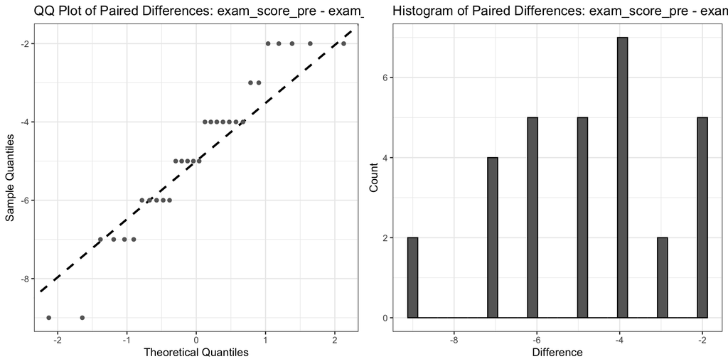

## Example 2

- Let’s check the normality assumption for the fitness score differences.

```r
zootopia_paired |> dependent_qq(col1 = fitness_score_intake,
                                col2 = fitness_score_6mo)
```

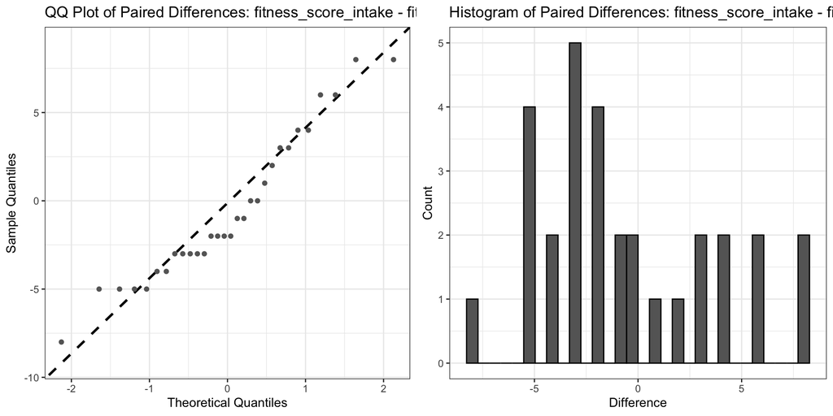

## Confidence Interval for $M_d$

- Just like the independent-samples case, the CI for a median difference is built from ranks.
- Instead of pairwise differences *between* two groups, we now work with *averages of pairs of differences* within the same set of $d_i$’s.
  - For every pair of differences $d_i$ and $d_j$, compute the Welsh average,

$$\dfrac{d_i + d_j}{2}$$

- The *median* of these averages is the Hodges-Lehmann estimate of the median difference.
- The CI is then found by ranking the Walsh averages and selecting upper and lower bounds.

## Ranking Paired Data

- The *differences* are ranked based on the absolute value of the difference.
- Then, ranks can be identified as “positive” or “negative” based on the original direction of the difference.

| *X* | *Y* | *D* | \|*D*\| | Rank |
| --- | --- | --- | --- | --- |
| 5 | 8 | -3 | 3 | $-$ 1.5 |
| 8 | 5 | 3 | 3 | $+$ 1.5 |
| 4 | 4 | 0 | 0 | ——— |

## Hypothesis Test for $M_d$

**Hypotheses**

**Two-Tailed**

$H_0: M_d = M_0$

$H_1: M_d \ne M_0$

**Left-Tailed**

$H_0: M_d \ge M_0$

$H_1: M_d < M_0$

**Right-Tailed**

$H_0: M_d \le M_0$

$H_1: M_d > M_0$

- $M_d$ is the population median of the differences,
  - Note that you must specify what $M_d$ is. e.g., $M_1-M_2$
- $M_0$ is the hypothesized median difference (often 0).

## Hypothesis Test for $M_d$

**Test Statistic**

## Statistical Inference on Dependent Medians (`R`)

- We will use the `dependent_medians()` function from `library(ssstats)` to perform statistical inference.
- Generic syntax:

```r
dataset_name |> dependent_medians(
  col1 = first_measurement,
  col2 = second_measurement,
  alternative = "two" | "less" | "greater",
  m = hypothesized_difference,
  alpha = alpha_level
  )
```

**1**

Pipes your dataset into `dependent_medians()`.

**2**

`col1`: the first paired measurement.

**3**

`col2`: the second paired measurement. **The function calculates `col1 - col2`, so order matters.**

**4**

`alternative`: the direction of the test; default is `two`.

**5**

`m`: the hypothesized median difference under $H_0$; default is 0.

**6**

`alpha`: the significance level; default is 0.05.

## Example 1

- Recall the research question:
  - Did recruits’ exam scores improve after coaching?
- **Hypotheses:**
  - $H_0: M_d \le 0$, where $M_d = M_{\text{post}} - M_{\text{pre}}$
  - $H_1: M_d > 0$
- For the `dependent_medians()` function, we will set
  - `mu = 0`
  - `alternative = "greater"`.

## Example 1

```r
zootopia_paired |> dependent_medians(col1 = exam_score_post,
                                     col2 = exam_score_pre,
                                     alternative = "greater")
```

```
Paired (dependent) medians

Complete pairs: 30
Effective pairs (non-zero differences): 30

M[exam_score_post] = 74
M[exam_score_pre] = 69.5
Hodges-Lehmann estimate of median difference: 5

95% CI for M[exam_score_post] − M[exam_score_pre]: (4, 5.5)

Hypotheses:
H₀: M[exam_score_post] − M[exam_score_pre] ≤ 0
H₁: M[exam_score_post] − M[exam_score_pre] > 0
Test statistic: T = 465
p-value: < 0.001
Conclusion: Reject the null hypothesis (p = < 0.001 < α = 0.050)
```

## Example 1

- **Hypotheses**
  - $H_0: M_d \le 0$, where $M_d = M_{\text{post}} - M_{\text{pre}}$
  - $H_1: M_d > 0$
- **Test Statistic and *p*-Value**
  - $T_0 = 465$
  - $p < 0.001$
- **Rejection Region**
  - Reject $H_0$ if $p < \alpha$; $\alpha = 0.05$
- **Conclusion and Interpretation**
  - Reject $H_0$. There is sufficient evidence to suggest that the exam scores improved after coaching.

## Example 2

- Recall the research question:
  - Does recruit fitness change between intake and the 6-month mark?

```r
zootopia_paired |> dependent_medians(col1 = fitness_score_6mo,
                                     col2 = fitness_score_intake)
```

[output not shown]

## Wrap Up

- Dependent (paired) data comes from the same subject measured twice.
  - We always work with the differences, $d_i = \text{col1}_i - \text{col2}_i$.
- The analysis you choose should match the shape of the differences:
  - If the differences meet normality (`dependent_means()`):
    - Interval estimate: CI for $\mu_d$
    - Paired $t$-test for $\mu_d$
  - If the differences do not meet normality (`dependent_medians()`):
    - Interval estimate: CI for $M_d$ (built from Walsh averages)
    - Wilcoxon signed-rank test for $M_d$